# Assignment3

## Question 2

Your friend conjectures that citrus/blackcurrant ﬂavored juice drinks have more added sugar because of the natural tartness of these ﬂavors. 1. Perform a t-test comparing the added sugar for citrus/blackcurrant drinks vs other ﬂavors. State your null and alternative hypotheses, pvalue, and ﬁnal conclusion. State which test (equal or unequal variance) you used and why.

```r
citrus <- juiceDrinks[juiceDrinks$Flavour=="Citrus-Blackcurrant",]
others <- juiceDrinks[juiceDrinks$Flavour=="Other",]
currantSugar = citrus$TotalSugar
otherSugar = others$TotalSugar
t.test(currantSugar, otherSugar, alternative="greater")
```

```
##
##  Welch Two Sample t-test
##
## data:  currantSugar and otherSugar
## t = -0.57396, df = 64.176, p-value = 0.716
## alternative hypothesis: true difference in means is greater than 0
## 95 percent confidence interval:
##  -7.51367      Inf
## sample estimates:
## mean of x mean of y
##  12.95789  14.88065
```

```r
var.test(currantSugar,otherSugar)
```

```
##
##  F test to compare two variances
##
## data:  currantSugar and otherSugar
## F = 0.9946, num df = 37, denom df = 30, p-value = 0.978
## alternative hypothesis: true ratio of variances is not equal to 1
## 95 percent confidence interval:
##  0.4911561 1.9637947
## sample estimates:
## ratio of variances
##          0.9946013
```

2. Produce a visualization suitable for comparing the added sugar in the two groups of drinks.

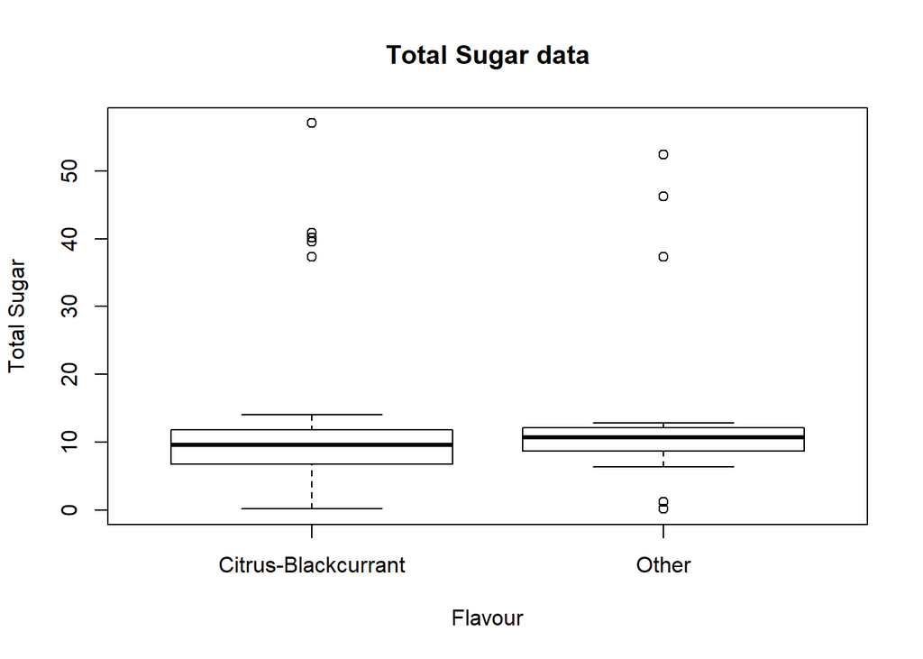

```r
boxplot(TotalSugar~Flavour, data=juiceDrinks, main="Total Sugar data", xlab="Flavour", ylab="Total Sugar")
```

3. Are there serious deviations from the assumptions of the t-test? Explain. A. There is no serious deviation. As sample size is greater than 30.
4. Comment on whether the mean is a good way to characterize the typical amount of added sugar for these two ﬂavour groups. A. As we have a skewed data. Mean is not a great measure.

## Question 3

Consider the data in the ﬁle “carseats-simple.csv.” The response is the number of carseats of a particular brand sold (in thousands) at diﬀerent locations over the course of a year. The predictor is the price in dollars of the carseat at that location. The data has been collected by a consumer agency that has no role in setting the price. 1. Produce a scatterplot of the data, including the line of best ﬁt.

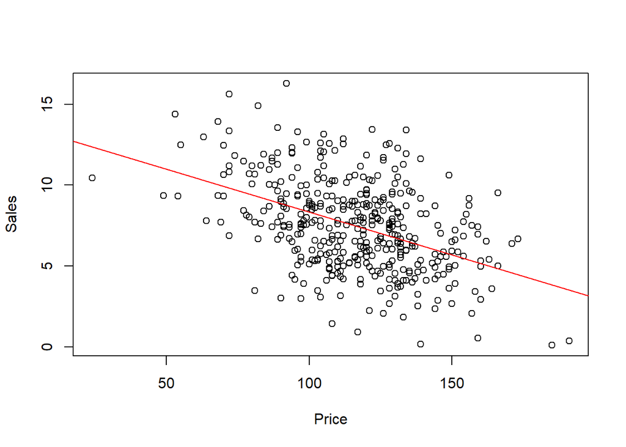

```r
carseats <- read.csv("carseats-simple.csv")

plot(x = carseats$Price, y = carseats$Sales, xlab = "Price", ylab = "Sales")

carseatsModel <- lm(Sales~Price, data = carseats)
carseatsCoeff <- carseatsModel$coefficients

abline(carseatsCoeff[1], carseatsCoeff[2], col="Red")
```

2. Test for a relationship between the sales and the price. Give your conclusion, referring to relevant portions of your output.

```r
(carseatsSummary <- summary(carseatsModel))
```

```
##
## Call:
## lm(formula = Sales ~ Price, data = carseats)
##
## Residuals:
##     Min      1Q  Median      3Q     Max
## -6.5227 -1.8454 -0.1464  1.6496  7.5113
##
## Coefficients:
##              Estimate Std. Error t value Pr(>|t|)
## (Intercept) 13.638582   0.632718  21.556   <2e-16 ***
## Price       -0.053042   0.005354  -9.908   <2e-16 ***
## ---
## Signif. codes:  0 '***' 0.001 '**' 0.01 '*' 0.05 '.' 0.1 ' ' 1
##
## Residual standard error: 2.532 on 398 degrees of freedom
## Multiple R-squared:  0.1978, Adjusted R-squared:  0.1958
## F-statistic: 98.16 on 1 and 398 DF,  p-value: < 2.2e-16
```

A. Based on R square, it is very small. Correlation coefficient is negative. The relationship between sales and the price is moderate negative correlated.

3. What is our uncertainty about the average number of sales for locations where the price is $150? Give a conﬁdence interval for this quantity.

```r
predict(carseatsModel, data.frame(Price = 150), interval = "confidence")
```

```
##        fit     lwr      upr
## 1 5.682271 5.24461 6.119931
```

4. Suppose we observe a location has set the price at $150. Give a prediction interval for the sales at that location. Explain why it is larger than the interval in (4).

```r
predict(carseatsModel, data.frame(Price = 150), interval="prediction")
```

```
##        fit      lwr      upr
## 1 5.682271 0.685397 10.67914
```

A. The standard error on the prediction is larger therefore the prediction interval will be wider than the confidence interval.

5. Suppose we change the price at a location previously charging $200 to $150. Should we use the interval above to predict sales at the new price? Explain any reservations you have. A. Observational value is not same as experimental data. In observational value we cannot know the causality. May be there are not many people and the price is set for $200 to cover the cost. Different levels may be set for different places. If we change the price we get other, this we get from experimental set up.

## Question 4

Consider the data in the ﬁle “turbine-simple.csv.” A gas turbine is an internal combustion engine used to generate electricity. A key measure of how well the turbine works is the heat rate, the energy input divided by the electricity generated (with lower heat rate being better). We are interested in how it is related to the airﬂow through the turbine. 1. Produce a scatterplot of the data. Describe the relationship between airﬂow and heat rate.

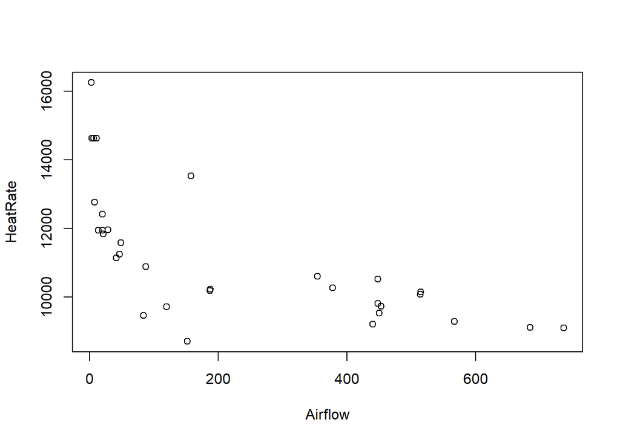

```r
turbine <- read.csv("turbine-simple.csv")
plot(HeatRate~Airflow, data=turbine)
```

```r
turbineModel <- lm(HeatRate~Airflow, data=turbine)
summary(turbineModel)
```

```
##
## Call:
## lm(formula = HeatRate ~ Airflow, data = turbine)
##
## Residuals:
##     Min      1Q  Median      3Q     Max
## -2860.3  -799.4  -139.4   540.6  3840.2
##
## Coefficients:
##              Estimate Std. Error t value Pr(>|t|)
## (Intercept) 12419.486    357.940  34.697  < 2e-16 ***
## Airflow        -5.561      1.116  -4.982 2.45e-05 ***
## ---
## Signif. codes:  0 '***' 0.001 '**' 0.01 '*' 0.05 '.' 0.1 ' ' 1
##
## Residual standard error: 1435 on 30 degrees of freedom
## Multiple R-squared:  0.4527, Adjusted R-squared:  0.4345
## F-statistic: 24.82 on 1 and 30 DF,  p-value: 2.452e-05
```

2. Try a few diﬀerent transformations of airﬂow, with the aim of making the relationship more linear. Show plots of the diﬀerent transformations you have tried (at least three) and indicate which you like the best.

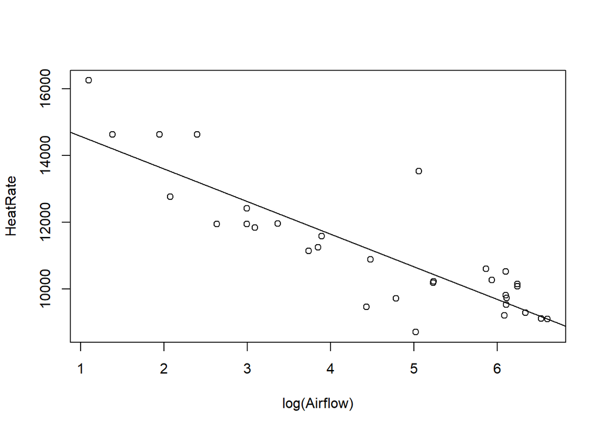

```r
turbineModel1 <- lm(HeatRate~log(Airflow), data=turbine)
plot(HeatRate~log(Airflow), data=turbine)
abline(turbineModel1)
```

```r
summary(turbineModel1)
```

```
##
## Call:
## lm(formula = HeatRate ~ log(Airflow), data = turbine)
##
## Residuals:
##     Min      1Q  Median      3Q     Max
## -1935.7  -578.7  -118.1   539.2  2911.2
##
## Coefficients:
##              Estimate Std. Error t value Pr(>|t|)
## (Intercept)   15556.7      509.5  30.536  < 2e-16 ***
## log(Airflow)   -976.7      106.3  -9.191 3.14e-10 ***
## ---
## Signif. codes:  0 '***' 0.001 '**' 0.01 '*' 0.05 '.' 0.1 ' ' 1
##
## Residual standard error: 992.7 on 30 degrees of freedom
## Multiple R-squared:  0.7379, Adjusted R-squared:  0.7292
## F-statistic: 84.47 on 1 and 30 DF,  p-value: 3.144e-10
```

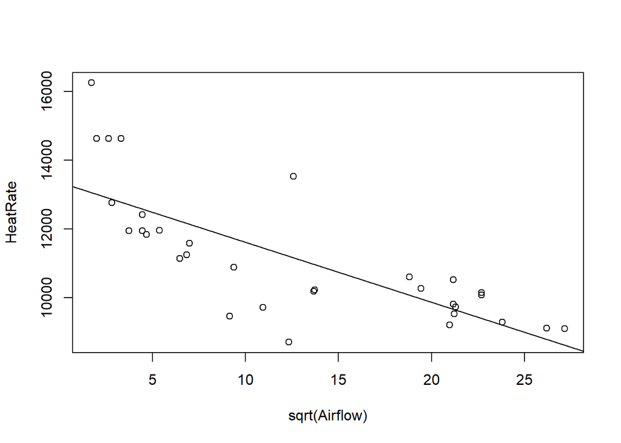

```r
turbineModel2 <- lm(HeatRate~sqrt(Airflow), data=turbine)
plot(HeatRate~sqrt(Airflow), data=turbine)
abline(turbineModel2)
```

```r
summary(turbineModel2)
```

```
##
## Call:
## lm(formula = HeatRate ~ sqrt(Airflow), data = turbine)
##
## Residuals:
##     Min      1Q  Median      3Q     Max
## -2498.4  -744.0  -117.1   559.8  3184.7
##
## Coefficients:
##               Estimate Std. Error t value Pr(>|t|)
## (Intercept)   13360.00     410.30  32.561  < 2e-16 ***
## sqrt(Airflow)  -174.19      27.27  -6.387 4.76e-07 ***
## ---
## Signif. codes:  0 '***' 0.001 '**' 0.01 '*' 0.05 '.' 0.1 ' ' 1
##
## Residual standard error: 1262 on 30 degrees of freedom
## Multiple R-squared:  0.5762, Adjusted R-squared:  0.5621
## F-statistic: 40.79 on 1 and 30 DF,  p-value: 4.756e-07
```

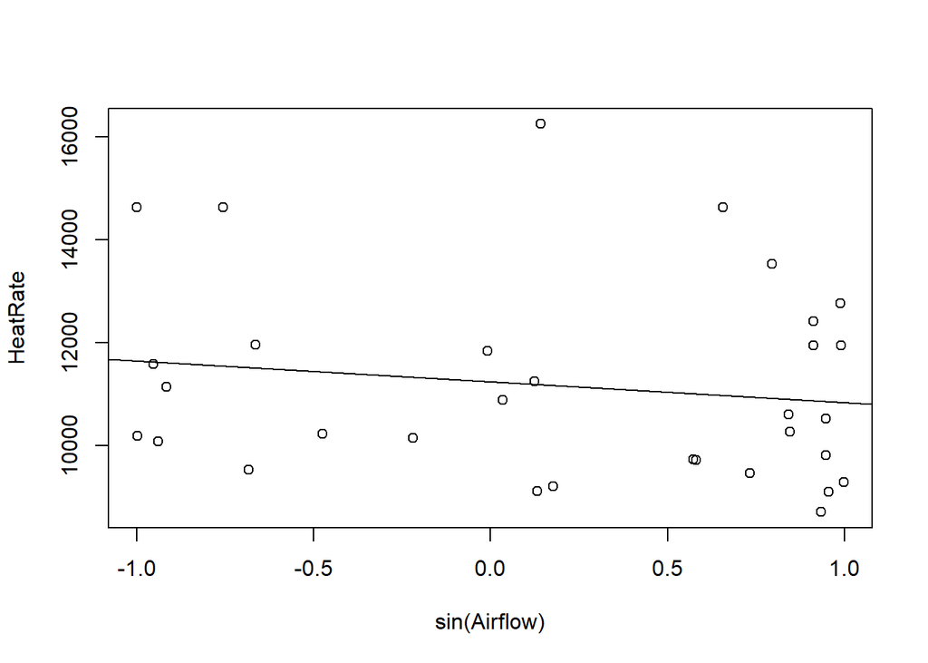

```r
turbineModel3 <- lm(HeatRate~sin(Airflow), data=turbine)
plot(HeatRate~sin(Airflow), data=turbine)
abline(turbineModel3)
```

```r
summary(turbineModel3)
```

```
##
## Call:
## lm(formula = HeatRate ~ sin(Airflow), data = turbine)
##
## Residuals:
##     Min      1Q  Median      3Q     Max
## -2153.2 -1466.1  -410.7  1080.4  5055.5
##
## Coefficients:
##              Estimate Std. Error t value Pr(>|t|)
## (Intercept)   11244.6      351.9   31.95   <2e-16 ***
## sin(Airflow)   -404.3      464.5   -0.87    0.391
## ---
## Signif. codes:  0 '***' 0.001 '**' 0.01 '*' 0.05 '.' 0.1 ' ' 1
##
## Residual standard error: 1915 on 30 degrees of freedom
## Multiple R-squared:  0.02463,    Adjusted R-squared:  -0.00788
## F-statistic: 0.7576 on 1 and 30 DF,  p-value: 0.391
```

3. Fit a linear model using the transformation you determined in (2). Show the prediction from this model as a curve on your scatterplot from (1). Create a prediction interval for the heat rate when the airﬂow is 300. Add this interval to your scatterplot as well.

```r
par(c(1,2));
```

```r
predict(turbineModel1, data.frame(Airflow = 300), interval="prediction")
```

```
##        fit      lwr      upr
## 1 9985.567 7910.194 12060.94
```

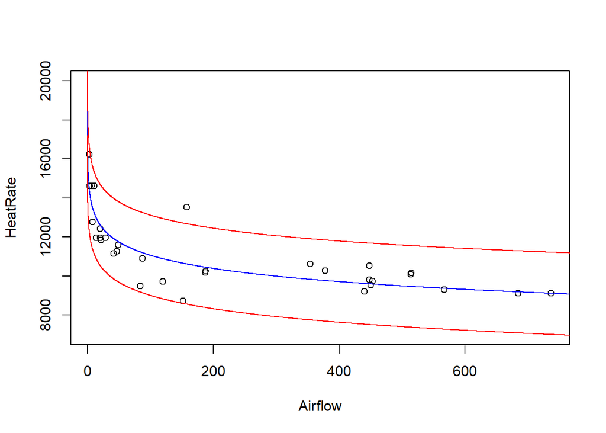

```r
predictValue <- predict(turbineModel1, data.frame(Airflow = seq(0, 800, .01)), interval="prediction")


plot(HeatRate~Airflow, data=turbine, ylim=c(7000, 20000))
lines(seq(0, 800, .01), predictValue[,1], col="blue")
lines(seq(0, 800, .01), predictValue[,2], col="red")
lines(seq(0, 800, .01), predictValue[,3], col="red")
```